# Generalized Linear Mixed Model, Poisson Analysis

## Dandy Lions Vs Kiwi Flowers

Danddy Lions compete with Kiwi Flowers for pollination. Their main pollinator is the bee. Scientists wanted to see if supplementing a bee’s diet would nehance their preference for kiwi flowers.

15 hives were assigned randomly 1 of the following three treatments:

Control (NO Supplement) Protein Supplement Syrup Supplement

At the entrance of each hive, pollen grains of each flower were left and were later counted for 4 days.

```r
treatment = c(
  replicate(20, "Syrup"), replicate(20, "Protein"), replicate(20, "Control")
)

hive = rep(c(1:15), each = 4)

sampling = rep(1:4, len = 60)

polen = c(
  236,  167,  227,  225,  306,  308,  241,  304,  36,  10,  2,
  19,  249,  208,  66,  43,  139,  145,  146,  110,  147,  140,
  153,  38,  129,  43,  42,  39,  35,  89,  100,  27,  111,  87,
  48,  25,  98,  76,  27,  59,  32,  50,  9,  31,  13,  1,  0,  6,
  130,  122,  127,  125,  31,  51,  11,  29,  11,  2,  1,  7
)

kiwi = data.frame(treatment, hive, sampling, polen)
```

```r
##Libraries Used

library(ggplot2)
library(ggpubr)
library(psych)
library(doBy)
library(lme4)
library(glmmTMB)
library(emmeans)
library(RVAideMemoire)
```

```r
#Functions Used
#Used for describing any ggplot used
descrPlot = function(df,x,y) {
  p = ggplot(data = df, aes(x = x, y = y))
}

#Used for Checking patterns in the residues
pearsonGraph = function(mdl)
{
  y = resid(mdl, type = "pearson")
  x = fitted(mdl)
  p = ggplot(kiwi, aes(x , y)) +
    geom_abline(slope = 0, intercept = 0, color = "red") +
    geom_point() +
    labs(x = "Ajusted Residues", y = "Pearson Residues")

  return(p)
}

#Used for checking residues per treatment
responseGraph = function(mdl)
{
  y = resid(mdl, type = "pearson")
  x = treatment
  p = ggplot(kiwi, aes(x , y)) +
    geom_boxplot(aes(colour = treatment)) +
    labs(x = "treatment", y = "Pearson residue")

  return(p)
}

#Used for Checking residues per hive
pearsonBox = function(mdl)

{
  y = resid(mdl, type = "pearson")
  x = hive
  p = ggplot(kiwi, aes(x, y)) +
    geom_boxplot(aes(colour = hive)) +
    labs(x = "Hive", y ="Pearson Residues")

  return(p)
}

#Used for Validating the model. Plots Response variable against
#what is expected to be seen by the proposed model
validGraph = function(mdl)
{
  y = polen
  x = fitted(mdl, type = "response")
  p = ggplot(kiwi, aes(x, y)) +
    geom_point() +
    geom_abline(slope = 1, intercept = 0) +
    labs(x = "Ajusted Residues", y = "Pollen Grains")
}
```

Firstly I will do a primary description analysis:

```r
kiwi$hive = factor(kiwi$hive)

##Descriptive analysis

firstGraph = descrPlot(kiwi, treatment, polen) +
  geom_boxplot() + geom_jitter(width = 0.1) +
  labs(x = "Treatment", y = "Pollen grains")

secondGraph = descrPlot(kiwi, sampling, polen) +
  geom_point(aes(colour = hive)) + facet_grid(. ~ treatment) +
  geom_line(aes(colour = hive)) + labs(x = "Sampling", y = "No. pollen grains")

summaryBy(polen ~ treatment, data = kiwi, FUN=c(mean, var, length))
```

|  | treatment | polen.mean | polen.var | polen.length |
| --- | --- | --- | --- | --- |
| 1 | Control | 39.45 | 2204.366 | 20 |
| 2 | Protein | 75.65 | 1876.976 | 20 |
| 3 | Syrup | 159.35 | 10730.555 | 20 |

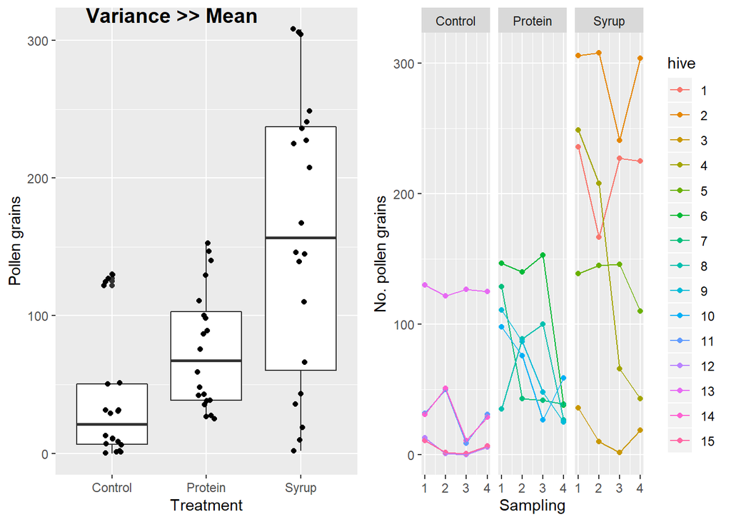

```r
ggarrange(firstGraph, secondGraph,
          labels = c("Variance >> Mean"))
```

The spaghetti plot seems to indicate that when there isn’t any supplement given, the number of polen grains left seems to depend of the hive activity. This can be observed due to the parallelism. On the other hand, the spaghetti plots for protein and syrup treatments seems to present a certain variation, some hives more than other. In these treatments the number of grains left seem to vary on something more than just on hive activity.

Let’s analyze!

I will present an initial model:

$Y$$_{ij}$ $=$ $Poisson$($\lambda$$_{ij}$)

$\eta$$_{i}$ $=$ $ln$($E(Y_{ij})$ $=$ $\beta$$_{0}$ $+$ $\beta$$_{1}$$*$$P$$_{ij}$ $+$ $\beta$$_{2}$$*$$A$$_{ij}$ $+$ $\alpha$$_{j}$

$E(Y_{i|j})$ $=$ $\mu$$_{i}$ = $e$$^{\eta_{i}}$ = $e$$^{\beta_{0}+\beta_{1}P_{ij}+\beta_{2}A_{ij}+\alpha_{j}}$

And this model assumes that the aleatory effects $\alpha$$_{j}$ $-$ NID(0, $\sigma$$^2$$_{hives}$)

```r
model1 = glmer(polen ~  treatment + (1|hive),
               data = kiwi, family = poisson)
#Assumtpions
m1g1 = pearsonGraph(model1)
m1g2 = responseGraph(model1)
m1g3 = pearsonBox(model1)
m1g4 = validGraph(model1)
```

This model takes hive as an aleatory effect and models the data according to a Poisson distribution. To see if the assumptions are met we study the residues of the model.

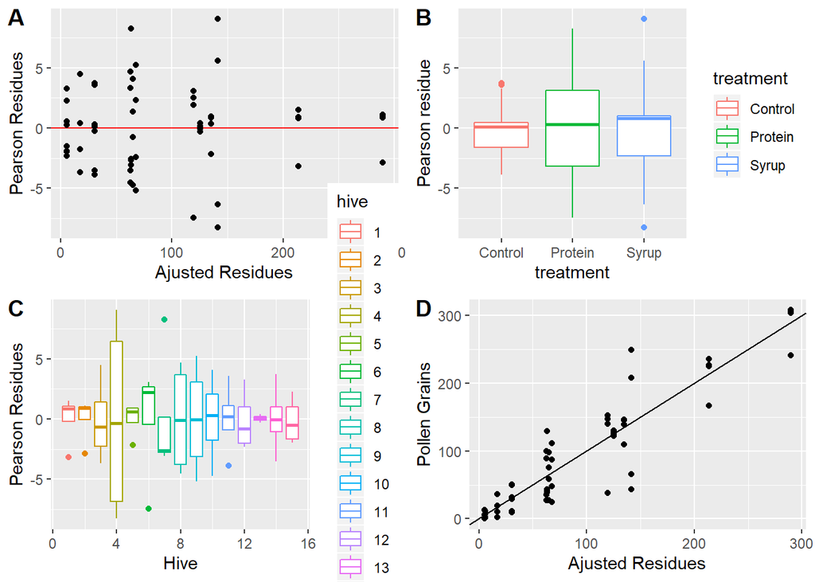

```r
ggarrange(m1g1, m1g2, m1g3, m1g4,
          labels = c("A", "B", "C", "D"))
```

As can be seen in graph A, there is a typical Funnel effect. Something to be expected from Poisson distributed data. There seems to be overdispersion both for treatment and hive ordered data. When the Ajusted values are compared to the Response variable values it is clear that the model doesn’t necessarily respond well.

Time to check the dispersion parameter.

```r
#Dispersion Parameter
"Degrees of freedom"
```

```
## [1] "Degrees of freedom"
```

```r
n = nrow(kiwi)
#Number of parameters estimated
k = length(fixef(model1)) + 1
#Dispersion formula
dispersion = sum((resid(model1, type = "pearson"))^2)/(n - k)
dispersion
```

```
## [1] 12.76808
```

Since there is over dispersion, but it is lower than 15, Alain Zuur suggests that analyzing the data would be best using Comway Maxwell Poisson distribution. But for the sake of showing how the negative binomial would look I will also analyze this option:

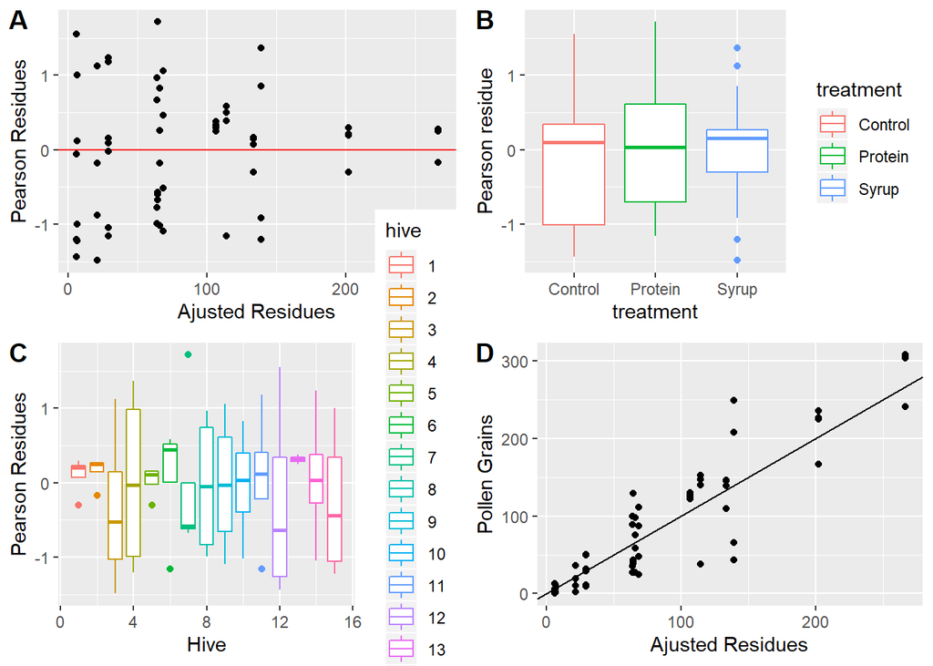

```r
model2 = glmmTMB(polen ~ treatment + (1|hive), data = kiwi,
                 family = "nbinom2")
#Assumptions
m2g1 = pearsonGraph(model2)
m2g2 = responseGraph(model2)
m2g3 = pearsonBox(model2)
m2g4 = validGraph(model2)

ggarrange(m2g1, m2g2, m2g3, m2g4,
          labels = c("A", "B", "C", "D"))
```

At a glance the funnel effect at graph A has been solved, and the overdispersion can no longer be seen when graphing the residues according to treatment or hives (since the maximum value in Y is under twice the standard deviation (2 : -2)). Though the problem at graph D seems to persist. The fitted values don’t ajust well to the observed values.

I will now try Comway Maxwell Poisson

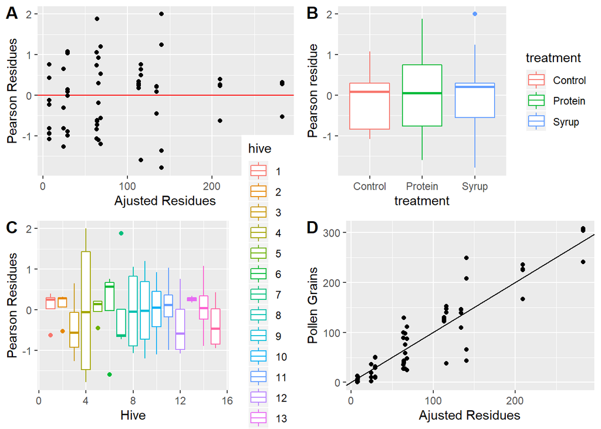

```r
#Conway Maxwell Poisson

model3 = glmmTMB(polen ~ treatment + (1|hive), data = kiwi,
                 family ="compois")

#Assumptions
m3g1 = pearsonGraph(model3)
m3g2 = responseGraph(model3)
m3g3 = pearsonBox(model3)
m3g4 = validGraph(model3)

ggarrange(m3g1, m3g2, m3g3, m3g4,
          labels = c("A", "B", "C", "D"))
```

The graph at D doesn’t seem to have improved at all but maybe it can be improved further. I will try adding another aleatory effect under “Observation”. It has been reported and proved that adding this type of aleatory effect (where each individual observation has its inherent effect) can improve the model. I will state this secondary correlation of the data as follows:

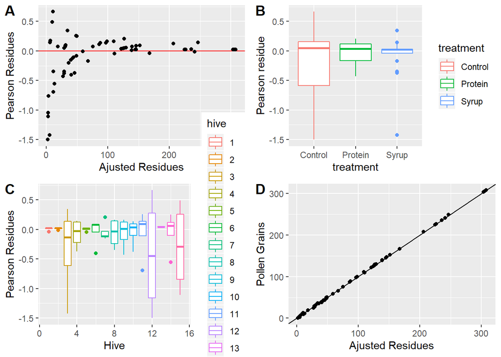

```r
#Adding the observation as an aleatory effect

#first I assign a unique identifier to each observation

id = 1:60
kiwi = cbind(id, kiwi[1:4])

model4 = glmmTMB(polen ~ treatment + (1|hive) + (1|id), data = kiwi,
                 family = poisson)
#dispersion parameter
#Since I have 2 aleatory effects the number of parameters estimated "extra" is 2.
#Assumptions
m4g1 = pearsonGraph(model4)
m4g2 = responseGraph(model4)
m4g3 = pearsonBox(model4)
m4g4 = validGraph(model4)

ggarrange(m4g1, m4g2, m4g3, m4g4,
          labels = c("A", "B", "C", "D"))
```

From the looks of these graphs, especially graph D one would say that this is the perfect model. WRONG! It would seem that the model can explain perfectly each observed value (Always suspect perfect models), and what’s more frightening is graph A. The pattern observed here is a clear indicator of a lack of Homoscedasticity. The cornerstone assumption in these models. If this is violated then any parameter estimated would lack any true value.

```r
k = length(fixef(model4)) + 2
dispersion = sum((resid(model4, type = "pearson"))^2)/ (n - k)
dispersion
```

```
## [1] 0.1854075
```

As can be seen from the dispersion parameter, the model suffers from underdispersion. This will severly affect the Estimated Errors.

Let’s compare the models thus far:

```r
modell = c("Neg Binom", "CMP", "Aleatory")
comp = cbind(modell,AIC(model2, model3, model4))
comp
```

|  | modell | df | AIC |
| --- | --- | --- | --- |
| model2 | Neg Binom | 5 | 626.5751 |
| model3 | CMP | 5 | 613.7348 |
| model4 | Aleatory | 5 | 630.3457 |

The AIC values indicate that model3 is the winner, but I always like to check and compare the values of Log(likelihood) of the best models (models 3 and 2)

```r
anova(model2, model3)
```

|  | Df | AIC | BIC | logLik | deviance | Chisq | Chi Df | Pr(>Chisq) |
| --- | --- | --- | --- | --- | --- | --- | --- | --- |
| model2 | 5 | 626.5751 | 637.0469 | -308.2876 | 616.5751 | NA | NA | NA |
| model3 | 5 | 613.7348 | 624.2066 | -301.8674 | 603.7348 | 12.84031 | 0 | 0 |

Since Model3 has better AIC value and Log(likelihood) values I will continue working with this model.

```r
#This patch is for using Emmeans for Tukey Tests
#Bolker Patch
recover.data.glmmTMB <- function(object, ...) {
  fcall <- getCall(object)
  recover.data(fcall,delete.response(terms(object)),
               attr(model.frame(object),"na.action"), ...)
}
lsm.basis.glmmTMB <- function (object, trms, xlev, grid, vcov.,
                               mode = "asymptotic", component="cond", ...) {
  if (mode != "asymptotic") stop("only asymptotic mode is available")
  if (component != "cond") stop("only tested for conditional component")
  if (missing(vcov.))
    V <- as.matrix(vcov(object)[[component]])
  else V <- as.matrix(.my.vcov(object, vcov.))
  dfargs = misc = list()
  if (mode == "asymptotic") {
    dffun = function(k, dfargs) NA
  }

  contrasts = attr(model.matrix(object), "contrasts")
  m = model.frame(trms, grid, na.action = na.pass, xlev = xlev)
  X = model.matrix(trms, m, contrasts.arg = contrasts)
  bhat = fixef(object)[[component]]
  if (length(bhat) < ncol(X)) {
    kept = match(names(bhat), dimnames(X)[[2]])
    bhat = NA * X[1, ]
    bhat[kept] = fixef(object)[[component]]
    modmat = model.matrix(trms, model.frame(object), contrasts.arg = contrasts)
    nbasis = estimability::nonest.basis(modmat)
  }
  else nbasis = estimability::all.estble
  list(X = X, bhat = bhat, nbasis = nbasis, V = V, dffun = dffun,
       dfargs = dfargs, misc = misc)
}
```

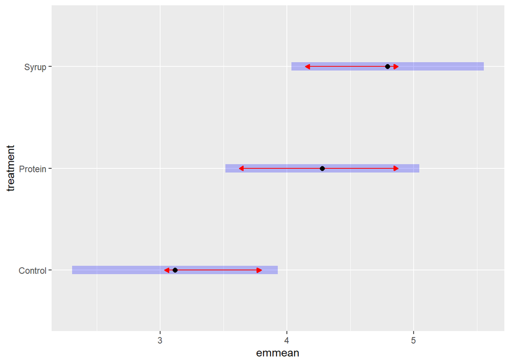

```r
#Linear Predictor Comparisons

Comp2 = emmeans(model3, pairwise ~ treatment) ##Tukey
plot(Comp2, comparison = TRUE)
```

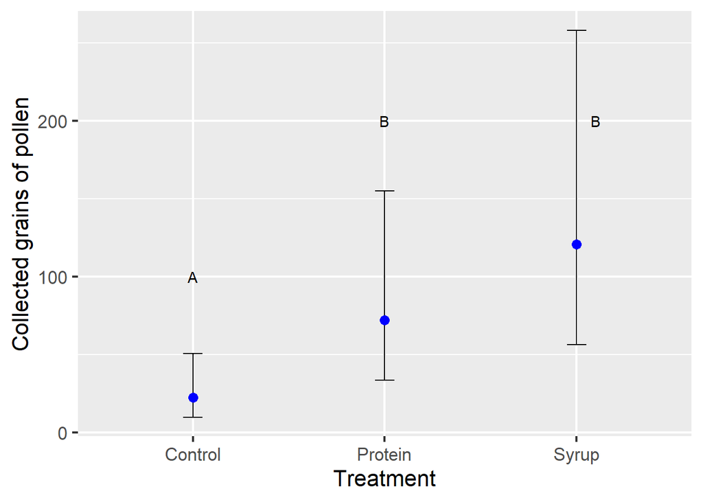

```r
#Response Variable Scale
Comp3 = emmeans(model3, pairwise ~ treatment, type = "response") #Tukeypor default
estad = as.data.frame(Comp3$emmeans)
estad$mean = (estad$rate)
estad$LI = (estad$lower.CL)
estad$UI = (estad$upper.CL)

compGraph = ggplot(estad, aes(x = estad$treatment, y = estad$mean)) +
  geom_errorbar(aes(ymin = estad$LI, ymax = estad$UI), width=.1) +
  geom_point(colour = "blue", size = 3) +
  labs(y = "Collected grains of pollen", x = "Treatment") +
  theme_grey(base_size = 16) +
  annotate("text", x = c(1,2,3.1), y = c(100, 200, 200), label = c("A", "B", "B"))
compGraph
```